```python
from IPython.display import HTML

HTML('''<script>
code_show=true;
function code_toggle() {
 if (code_show){
 $('div.input').hide();
 } else {
 $('div.input').show();
 }
 code_show = !code_show
}
$( document ).ready(code_toggle);
</script>
<form action="javascript:code_toggle()"><input type="submit" value="Click here to toggle on/off the raw code."></form>''')
```

# Skin Cancer Data Assignment

### Problem statement

To build a CNN based model which can accurately detect melanoma. Melanoma is a type of cancer that can be deadly if not detected early. It accounts for 75% of skin cancer deaths. A solution which can evaluate images and alert the dermatologists about the presence of melanoma has the potential to reduce a lot of manual effort needed in diagnosis.

### Importing all the important libraries

```python
import os
import gc
import PIL
import pathlib
import itertools
from glob import glob

import matplotlib.pyplot as plt
import matplotlib.image as img
import seaborn as sns

import numpy as np
import pandas as pd

from sklearn.metrics import confusion_matrix

import tensorflow as tf
from tensorflow import keras
from tensorflow.keras import layers
from tensorflow.keras import Sequential, Model
from tensorflow.keras.layers import Input, Dense, Layer
from tensorflow.keras.layers import Concatenate, Add
from tensorflow.keras.layers import Conv2D, MaxPool2D, GlobalAveragePooling2D, Dropout, BatchNormalization

from tensorflow.keras.utils import plot_model

from albumentations import (Compose, RandomBrightness, RandomBrightnessContrast, JpegCompression, HueSaturationValue,
                            RandomContrast, HorizontalFlip, Rotate, VerticalFlip)

import logging
logging.getLogger('tensorflow').disabled = True
```

### Seed Initilization

```python
import random

DEFAULT_RANDOM_SEED = 13

def seedBasic(seed=DEFAULT_RANDOM_SEED):
    random.seed(seed)
    os.environ['PYTHONHASHSEED'] = str(seed)
    np.random.seed(seed)

# tensorflow random seed
import tensorflow as tf
def seedTF(seed=DEFAULT_RANDOM_SEED):
    tf.random.set_seed(seed)

# basic + tensorflow
def seedEverything(seed=DEFAULT_RANDOM_SEED):
    seedBasic(seed)
    seedTF(seed)
```

```python
seedEverything(DEFAULT_RANDOM_SEED)
```

This assignment uses a dataset of about 2357 images of skin cancer types. The dataset contains 9 sub-directories in each train and test subdirectories. The 9 sub-directories contains the images of 9 skin cancer types respectively.

```python
# Defining the path for train and test images
data_dir_train = pathlib.Path("../../data/CNN_assignment/Train")
data_dir_test = pathlib.Path('../../data/CNN_assignment/Test')
```

```python
image_count_train = len(list(data_dir_train.glob('*/*.jpg')))
print(image_count_train)
image_count_test = len(list(data_dir_test.glob('*/*.jpg')))
print(image_count_test)
```

```
2239
118
```

### Loading Data

Let's load these images off disk using the helpful image_dataset_from_directory utility.

### Create a Dataset

Define some parameters for the loader:

```python
batch_size = 32
img_height = 180
img_width = 180
```

Use 80% of the images for training, and 20% for validation.

```python
train_ds = tf.keras.preprocessing.image_dataset_from_directory(
    data_dir_train,
    validation_split=0.2,
    subset="training",
    seed=DEFAULT_RANDOM_SEED,
    image_size=(img_height, img_width),
    batch_size=batch_size)
```

```
Found 2239 files belonging to 9 classes.
Using 1792 files for training.
```

```python
val_ds = tf.keras.preprocessing.image_dataset_from_directory(
    data_dir_train,
    validation_split=0.2,
    subset="validation",
    seed=DEFAULT_RANDOM_SEED,
    image_size=(img_height, img_width),
    batch_size=batch_size)
```

```
Found 2239 files belonging to 9 classes.
Using 447 files for validation.
```

```python
test_ds = tf.keras.preprocessing.image_dataset_from_directory(
    data_dir_test,
    validation_split=0.9999,
    subset="validation",
    seed=DEFAULT_RANDOM_SEED,
    image_size=(img_height, img_width),
    batch_size=batch_size)
```

```
Found 118 files belonging to 9 classes.
Using 117 files for validation.
```

```python
class_names = train_ds.class_names
print(class_names)
```

```
['actinic keratosis', 'basal cell carcinoma', 'dermatofibroma', 'melanoma', 'nevus', 'pigmented benign keratosis', 'seborrheic keratosis', 'squamous cell carcinoma', 'vascular lesion']
```

### Visualize the data

```python
def visualize_class(class_name):
    return img.imread(str(list(data_dir_train.glob(class_names[class_name]+'/*.jpg'))[1]))
```

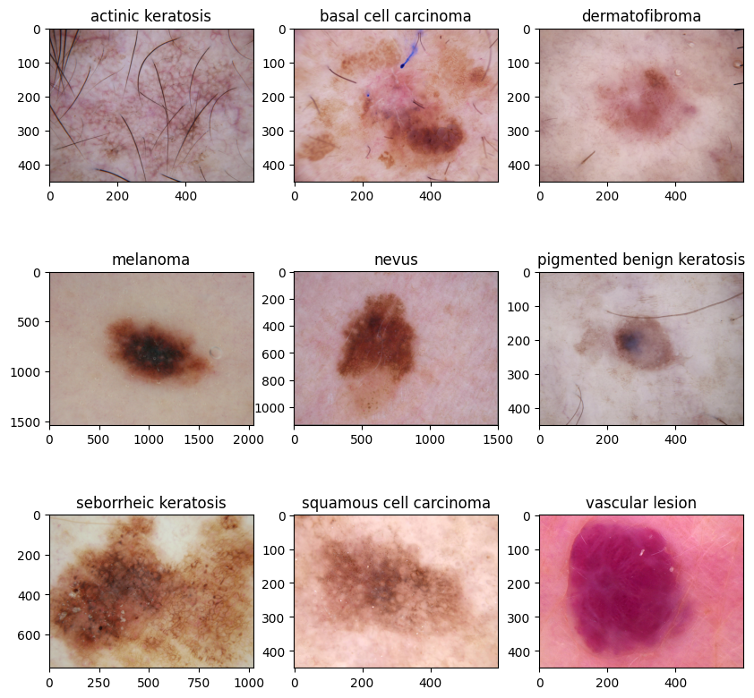

```python
num_classes = len(class_names)
plt.figure(figsize=(10, 10))
for i in range(num_classes):
    plt.subplot(3, 3, i+1)
    image = visualize_class(i)
    plt.title(class_names[i])
    plt.imshow(image)
```

The `image_batch` is a tensor of the shape `(32, 180, 180, 3)`. This is a batch of 32 images of shape `180x180x3` (the last dimension refers to color channels RGB). The `label_batch` is a tensor of the shape `(32,)`, these are corresponding labels to the 32 images.

`Dataset.cache()` keeps the images in memory after they're loaded off disk during the first epoch.

`Dataset.prefetch()` overlaps data preprocessing and model execution while training.

```python
AUTOTUNE = tf.data.experimental.AUTOTUNE

train_ds = train_ds.cache().shuffle(1000).prefetch(buffer_size=AUTOTUNE)
val_ds = val_ds.cache().prefetch(buffer_size=AUTOTUNE)
```

## Model : SqueezeNet

I've built a modified version of SqueezeNet.

- SqueezeNet : This model is very popular due to its small size and high returns of accuracy per computation just like ENet.
- Why did I choose it :
  1. Small Model Size : Can be efficiently deployed in phone cameras and doctors/users can classify the type on the phone itself without visiting the Hospital
  2. Faster Training : Lesser Carbon Footprint
  3. Very high Return for Accuracy vs Number of Computation
- Modifications : Added BatchNorm after every Conv2d Layers so that training is faster, smoother and better so the number of parameters from the actual SqueezeNet and mine would be a bit different.

### Architecture :

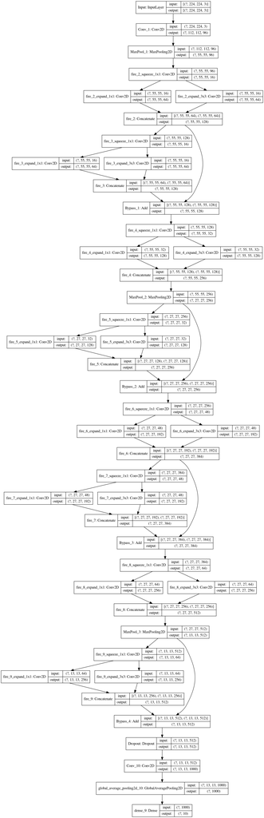

### Model Skeleton

```python
one = (1, 1)
two = (2, 2)
three = (3, 3)
five = (5, 5)
seven = (7, 7)
thirteen = (13, 13)

input_shape = (224, 224, 3)
```

```python
class FireModule(object):
    """
    Fire Module computed as per the SqueezeNet paper
    """

    def __init__(self, layer_number: int, activation: str, kernel_initializer: str) -> None:
        """
        Constructor

        Arguments:
          layer_number       : Index of the Fire Module
          activation         : Activation to be used
          kernel_initializer : Kernel Weight Initialization technique

        Returns:
          None
        """

        self.layer_number = layer_number
        self.activation = activation
        self.kernel_initializer = kernel_initializer

    def build_module(self, fire_input: Layer) -> Layer:
        """
        Build the SqueezeNet

        Arguments:
          fire_input       : Input to Fire Module

        Returns:
          model            : SqueezeNet
        """

        global one, three, five

        output_size = 128 * (1 + (self.layer_number//2))

        squeeze_1x1_filters = 16 * (1 + (self.layer_number//2))
        expand_1x1_filters = expand_3x3_filters = output_size//2

        squeeze_1x1 = Conv2D(name=f'fire_{self.layer_number+2}_squeeze_1x1',
            filters=squeeze_1x1_filters, kernel_size=one, strides=1, padding='valid', activation=self.activation,
            kernel_initializer=self.kernel_initializer)(fire_input)
        bn_1 = BatchNormalization(momentum=0.9)(squeeze_1x1)
        expand_1x1 = Conv2D(name=f'fire_{self.layer_number+2}_expand_1x1',
            filters=expand_1x1_filters, kernel_size=one, strides=1, padding='valid', activation=self.activation,
            kernel_initializer=self.kernel_initializer)(bn_1)
        bn_2 = BatchNormalization(momentum=0.9)(expand_1x1)
        expand_3x3 = Conv2D(name=f'fire_{self.layer_number+2}_expand_3x3',
            filters=expand_3x3_filters, kernel_size=three, strides=1, padding='same', activation=self.activation,
            kernel_initializer=self.kernel_initializer)(bn_2)
        bn_3 = BatchNormalization(momentum=0.9)(expand_3x3)

        fire = Concatenate(name=f'fire_{self.layer_number+2}')([bn_2, bn_3])

        return fire


class SqueezeNet(object):
    """
    SqueezeNet Architecture
    """

    def __init__(self, activation: str='relu', kernel_initializer: str='glorot_uniform') -> None:
        """
        Constructor

        Arguments:
          activation         : Activation to be used
          kernel_initializer : Kernel Weight Initialization technique

        Returns:
          None
        """

        self.activation = activation
        self.kernel_initializer = kernel_initializer

    def vanilla_model(self, input_shape: tuple=(224, 224, 3), n_classes: int=1000) -> None:
        """
        Vanilla Implementation of SqueezeNet

        Arguments:
          input_shape         : Input Shape of the images
          n_classes           : Number of output classes

        Returns:
          None
        """

        inp = Input(shape=input_shape, name='Input')

        # Conv1 Layer
        conv_1 = Conv2D(name="Conv_1",
            filters=96, kernel_size=seven, strides=2, padding='same', activation=self.activation, kernel_initializer=self.kernel_initializer)(inp)
        bn_1 = BatchNormalization(momentum=0.9)(conv_1)
        maxpool_1 = MaxPool2D(name="MaxPool_1",
            pool_size=three, strides=2)(bn_1)

        # Fire 2-4
        fire_2 = FireModule(layer_number=0, activation=self.activation,
                            kernel_initializer=self.kernel_initializer).build_module(maxpool_1)
        fire_3 = FireModule(layer_number=1, activation=self.activation,
                            kernel_initializer=self.kernel_initializer).build_module(fire_2)
        fire_4 = FireModule(layer_number=2, activation=self.activation,
                            kernel_initializer=self.kernel_initializer).build_module(fire_3)

        # Max Pool after Fire4 Module
        maxpool_2 = MaxPool2D(name="MaxPool_2",
            pool_size=three, strides=2)(fire_4)

        # Fire 5-8
        fire_5 = FireModule(layer_number=3, activation=self.activation, kernel_initializer=self.kernel_initializer).build_module(maxpool_2)
        fire_6 = FireModule(layer_number=4, activation=self.activation, kernel_initializer=self.kernel_initializer).build_module(fire_5)
        fire_7 = FireModule(layer_number=5, activation=self.activation, kernel_initializer=self.kernel_initializer).build_module(fire_6)
        fire_8 = FireModule(layer_number=6, activation=self.activation, kernel_initializer=self.kernel_initializer).build_module(fire_7)

        # Max Pool after Fire8 Module
        maxpool_3 = MaxPool2D(name="MaxPool_3",
            pool_size=three, strides=2)(fire_8)

        fire_9 = FireModule(layer_number=7, activation=self.activation, kernel_initializer=self.kernel_initializer).build_module(maxpool_3)

        # Dropout
        dropout = Dropout(0.5, name="Dropout")(fire_9)

        # Conv10 layer
        conv_10 = Conv2D(name="Conv_10",
            filters=1000, kernel_size=one, strides=1, padding='valid', activation=self.activation, kernel_initializer=self.kernel_initializer)(dropout)
        bn_2 = BatchNormalization(momentum=0.9)(conv_10)
        gap_11 = GlobalAveragePooling2D()(bn_2)


        if n_classes != 1000:
            # Add Dense(n_classes) and ouput == Dense layer
            out = Dense(n_classes, activation='softmax')(gap_11)
        else:
            out = gap_11

        self.model = Model(inputs=inp, outputs=out)


    def bypass_model(self, input_shape: tuple=(224, 224, 3), n_classes: int=1000) -> None:
        """
        Residual Inspired Bypass Implementation of SqueezeNet

        Arguments:
          input_shape         : Input Shape of the images
          n_classes           : Number of output classes

        Returns:
          None
        """

        inp = Input(shape=input_shape, name='Input')

        # Conv1 Layer
        conv_1 = Conv2D(name="Conv_1",
            filters=96, kernel_size=seven, strides=2, padding='same', activation=self.activation, kernel_initializer=self.kernel_initializer)(inp)
        bn_1 = BatchNormalization(momentum=0.9)(conv_1)
        maxpool_1 = MaxPool2D(name="MaxPool_1",
            pool_size=three, strides=2)(bn_1)

        # Fire 2-4
        fire_2 = FireModule(layer_number=0, activation=self.activation, kernel_initializer=self.kernel_initializer).build_module(maxpool_1)
        fire_3 = FireModule(layer_number=1, activation=self.activation, kernel_initializer=self.kernel_initializer).build_module(fire_2)
        bypass_1 = Add(name="Bypass_1")([fire_2, fire_3])
        fire_4 = FireModule(layer_number=2, activation=self.activation, kernel_initializer=self.kernel_initializer).build_module(bypass_1)

        # Max Pool after Fire4 Module
        maxpool_2 = MaxPool2D(name="MaxPool_2",
            pool_size=three, strides=2)(fire_4)

        # Fire 5-8
        fire_5 = FireModule(layer_number=3, activation=self.activation, kernel_initializer=self.kernel_initializer).build_module(maxpool_2)
        bypass_2 = Add(name="Bypass_2")([maxpool_2, fire_5])
        fire_6 = FireModule(layer_number=4, activation=self.activation, kernel_initializer=self.kernel_initializer).build_module(bypass_2)
        fire_7 = FireModule(layer_number=5, activation=self.activation, kernel_initializer=self.kernel_initializer).build_module(fire_6)
        bypass_3 = Add(name="Bypass_3")([fire_6, fire_7])
        fire_8 = FireModule(layer_number=6, activation=self.activation, kernel_initializer=self.kernel_initializer).build_module(bypass_3)

        # Max Pool after Fire8 Module
        maxpool_3 = MaxPool2D(name="MaxPool_3",
            pool_size=three, strides=2)(fire_8)

        fire_9 = FireModule(layer_number=7, activation=self.activation, kernel_initializer=self.kernel_initializer).build_module(maxpool_3)
        bypass_4 = Add(name="Bypass_4")([maxpool_3, fire_9])

        # Dropout
        dropout = Dropout(0.5, name="Dropout")(bypass_4)

        # Conv10 layer
        conv_10 = Conv2D(name="Conv_10",
            filters=1000, kernel_size=one, strides=1, padding='valid', activation=self.activation, kernel_initializer=self.kernel_initializer)(dropout)
        bn_2 = BatchNormalization(momentum=0.9)(conv_10)
        gap_11 = GlobalAveragePooling2D()(bn_2)

#         fcn = Dense(256, activation='relu')(gap_11)

        if n_classes != 1000:
            out = Dense(n_classes, activation='softmax')(gap_11)
        else:
            out = gap_11

        self.model = Model(inputs=inp, outputs=out)


    def build_model(self, input_shape: tuple=(224, 224, 3), n_classes: int=1000, choice: str='vanilla') -> Model:
        """
        Build SqueezeNet

        Arguments:
          input_shape         : Input Shape of the images
          n_classes           : Number of output classes
          choice              : Type of architecture (vanilla/bypass)
        Returns:
          model               : SqueezeNet Model
        """

        if choice == "vanilla":
            self.vanilla_model(input_shape, n_classes)
        else:
            self.bypass_model(input_shape, n_classes)

        return self.model
```

```python
snet = SqueezeNet()

model = snet.build_model(n_classes=9, choice='bypass', input_shape=(180, 180, 3))
model.summary()
```

```
Model: "model_6"
__________________________________________________________________________________________________
 Layer (type)                   Output Shape         Param #     Connected to
==================================================================================================
 Input (InputLayer)             [(None, 180, 180, 3  0           []
                                )]

 Conv_1 (Conv2D)                (None, 90, 90, 96)   14208       ['Input[0][0]']

 batch_normalization_130 (Batch  (None, 90, 90, 96)  384         ['Conv_1[0][0]']
 Normalization)

 MaxPool_1 (MaxPooling2D)       (None, 44, 44, 96)   0           ['batch_normalization_130[0][0]']

 fire_2_squeeze_1x1 (Conv2D)    (None, 44, 44, 16)   1552        ['MaxPool_1[0][0]']

 batch_normalization_131 (Batch  (None, 44, 44, 16)  64          ['fire_2_squeeze_1x1[0][0]']
 Normalization)

 fire_2_expand_1x1 (Conv2D)     (None, 44, 44, 64)   1088        ['batch_normalization_131[0][0]']

 batch_normalization_132 (Batch  (None, 44, 44, 64)  256         ['fire_2_expand_1x1[0][0]']
 Normalization)

 fire_2_expand_3x3 (Conv2D)     (None, 44, 44, 64)   36928       ['batch_normalization_132[0][0]']

 batch_normalization_133 (Batch  (None, 44, 44, 64)  256         ['fire_2_expand_3x3[0][0]']
 Normalization)

 fire_2 (Concatenate)           (None, 44, 44, 128)  0           ['batch_normalization_132[0][0]',
                                                                  'batch_normalization_133[0][0]']

 fire_3_squeeze_1x1 (Conv2D)    (None, 44, 44, 16)   2064        ['fire_2[0][0]']

 batch_normalization_134 (Batch  (None, 44, 44, 16)  64          ['fire_3_squeeze_1x1[0][0]']
 Normalization)

 fire_3_expand_1x1 (Conv2D)     (None, 44, 44, 64)   1088        ['batch_normalization_134[0][0]']

 batch_normalization_135 (Batch  (None, 44, 44, 64)  256         ['fire_3_expand_1x1[0][0]']
```

[output cut: 138 more lines]

```

 batch_normalization_155 (Batch  (None, 10, 10, 1000  4000       ['Conv_10[0][0]']
 Normalization)                 )

 global_average_pooling2d_6 (Gl  (None, 1000)        0           ['batch_normalization_155[0][0]']
 obalAveragePooling2D)

 dense_6 (Dense)                (None, 9)            9009        ['global_average_pooling2d_6[0][0
                                                                 ]']

==================================================================================================
Total params: 2,932,217
Trainable params: 2,924,265
Non-trainable params: 7,952
__________________________________________________________________________________________________
```

### Compile the model

- Optimizer : Choosing Adam as the Optimizer as its very widely used and is efficient and fast!
- Loss : SparseCategoricalCrossEntropy because we have a multiclass classification problem at hand.
- Metric : Accuracy

```python
opt = tf.keras.optimizers.Adam(learning_rate=0.001)
model.compile(optimizer= opt,
              loss= tf.keras.losses.SparseCategoricalCrossentropy(from_logits=False),
              metrics=['accuracy'])
```

### Training the model

```python
es_cb = tf.keras.callbacks.EarlyStopping(monitor='val_accuracy', patience=10, restore_best_weights=True, mode='max', verbose=1)
rdr_cb = tf.keras.callbacks.ReduceLROnPlateau(monitor='val_loss', factor=0.5, patience=5, verbose=1, cooldown=5)
ckpt_cb = tf.keras.callbacks.ModelCheckpoint(filepath="baseline_snet_weights.hdf5", monitor="val_accuracy", verbose=1, save_best_only=True, save_weights_only=False)
```

```python
epochs = 40
history = model.fit(
    train_ds,
    validation_data=val_ds,
    epochs=epochs,
    callbacks=[es_cb, rdr_cb, ckpt_cb],
)
```

[output not shown]

```python
print(f"Early Stopping at Epoch : {es_cb.best_epoch + 1}")
print(f"Train Acc at Epoch {es_cb.best_epoch} : {history.history['accuracy'][es_cb.best_epoch]: .2f}")
print(f"Valid Acc at Epoch {es_cb.best_epoch} : {history.history['val_accuracy'][es_cb.best_epoch]: .2f}")
```

```
Early Stopping at Epoch : 25
Train Acc at Epoch 24 :  0.75
Valid Acc at Epoch 24 :  0.59
```

### Visualizing training results

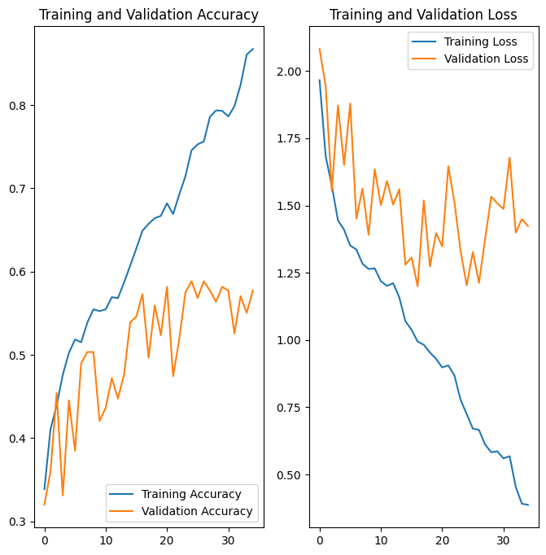

```python
acc = history.history['accuracy']
val_acc = history.history['val_accuracy']

loss = history.history['loss']
val_loss = history.history['val_loss']

epochs_range = range(len(acc))

plt.figure(figsize=(11, 4))
plt.subplot(1, 2, 1)
plt.plot(epochs_range, acc, label='Training Accuracy')
plt.plot(epochs_range, val_acc, label='Validation Accuracy')
plt.legend(loc='lower right')
plt.title('Training and Validation Accuracy')

plt.subplot(1, 2, 2)
plt.plot(epochs_range, loss, label='Training Loss')
plt.plot(epochs_range, val_loss, label='Validation Loss')
plt.legend(loc='upper right')
plt.title('Training and Validation Loss')
plt.show()
```

Our Model early stopped at Epoch 25 and from the graph above we can analyze that after epoch 25 the model started to overfit heavily.

### Baseline SqueezeNet Metrics :

- Train Acc : 75%
- Valid Acc : 59%

### Confusion Matrix

```python
val_preds = model.predict(val_ds)
val_preds.shape
```

```
(447, 9)
```

```python
val_preds = np.argmax(val_preds, axis=1)
val_preds.shape
```

```
(447,)
```

```python
def plot_confusion_matrix(cm, classes,
                        normalize=False,
                        title='Confusion matrix',
                        cmap=plt.cm.Blues):
    """
    This function prints and plots the confusion matrix.
    Normalization can be applied by setting `normalize=True`.
    """
    plt.imshow(cm, interpolation='nearest', cmap=cmap)
    plt.title(title)
    plt.colorbar()
    tick_marks = np.arange(len(classes))
    plt.xticks(tick_marks, classes, rotation=45)
    plt.yticks(tick_marks, classes)

    if normalize:
        cm = cm.astype('float') / cm.sum(axis=1)[:, np.newaxis]
        print("Normalized confusion matrix")
    else:
        print('Confusion matrix, without normalization')
    print(cm)

    thresh = cm.max() / 2.
    for i, j in itertools.product(range(cm.shape[0]), range(cm.shape[1])):
        plt.text(j, i, cm[i, j],
            horizontalalignment="center",
            color="black" if cm[i, j] > thresh else "black")

    plt.tight_layout()
    plt.ylabel('True label')
    plt.xlabel('Predicted label')
```

```python
val_y = np.concatenate([y for x, y in val_ds], axis=0)
val_y.shape
```

```
(447,)
```

```
Confusion matrix, without normalization
[[ 1  3  1  4  5  6  0  0  3]
 [ 2 14  0 19 10 18  0  6  2]
 [ 0  4  1  8  6  8  0  1  2]
 [ 6  8  5 17 10 19  1  3  5]
 [ 2 13  4 12 11 25  0  6  7]
 [ 2 16  5 17 15 26  0  9  5]
 [ 2  2  0  5  1  6  0  1  0]
 [ 0  3  2  7  3  8  0  6  1]
 [ 0  5  2  6  5  8  0  0  1]]
```

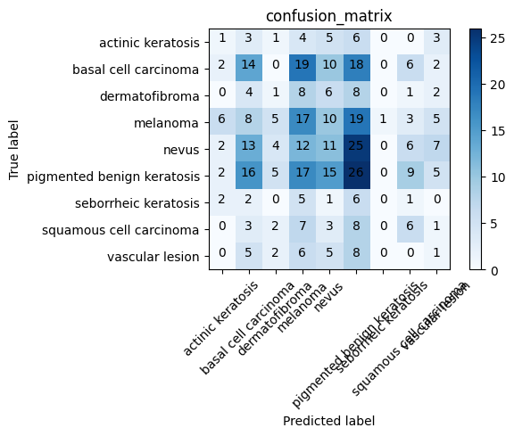

```python
cm_plot_labels = class_names

cm = confusion_matrix(y_true=val_y, y_pred=val_preds)
plot_confusion_matrix(cm=cm, classes=cm_plot_labels, title='confusion_matrix')
```

From the confusion matrix we can see that the classes which contain very less samples are getting classified very incorrectly :

- 'actinic keratosis' - 1 Correct Prediction
- 'dermatofibroma' - 1 Correct Prediction
- 'seborrheic keratosis' - 0 Correct Prediction
- 'squamous cell carcinoma' - 6 Correct Prediction
- 'vascular lesion' - 1 Correct Prediction

It seems that we need to balance these classes to get a good accuracy and for the model to learn better.

### Class Distribution

```
total training image count = 2239

-------------------------------------
Class name =  actinic keratosis
count      =  114
proportion =  0.05091558731576597
-------------------------------------
Class name =  basal cell carcinoma
count      =  376
proportion =  0.16793211255024565
-------------------------------------
Class name =  dermatofibroma
count      =  95
proportion =  0.04242965609647164
-------------------------------------
Class name =  melanoma
count      =  438
proportion =  0.19562304600267977
-------------------------------------
Class name =  nevus
count      =  357
proportion =  0.15944618133095131
-------------------------------------
Class name =  pigmented benign keratosis
count      =  462
proportion =  0.20634211701652524
-------------------------------------
Class name =  seborrheic keratosis
count      =  77
proportion =  0.03439035283608754
-------------------------------------
Class name =  squamous cell carcinoma
count      =  181
proportion =  0.08083966056275123
-------------------------------------
Class name =  vascular lesion
count      =  139
proportion =  0.062081286288521664
-------------------------------------
```

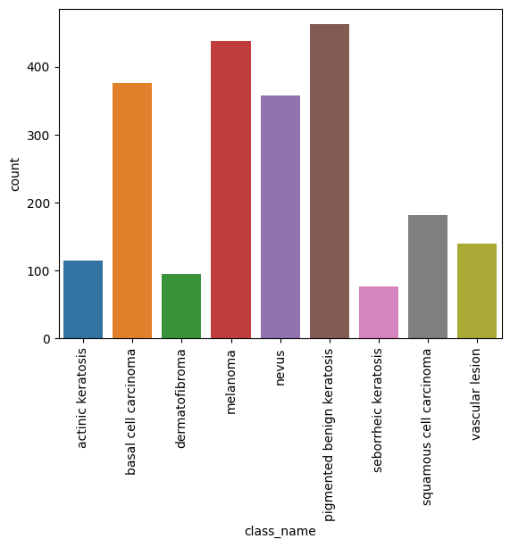

```python
num_classes = len(class_names)
total = 0
all_count = []
class_name = []
for i in range(num_classes):
    count = len(list(data_dir_train.glob(class_names[i]+'/*.jpg')))
    total += count
print("total training image count = {} \n".format(total))
print("-------------------------------------")
for i in range(num_classes):
    count = len(list(data_dir_train.glob(class_names[i]+'/*.jpg')))
    print("Class name = ",class_names[i])
    print("count      = ",count)
    print("proportion = ",count/total)
    print("-------------------------------------")
    all_count.append(count)
    class_name.append(class_names[i])

temp_df = pd.DataFrame(list(zip(all_count, class_name)), columns = ['count', 'class_name'])
sns.barplot(data=temp_df, y="count", x="class_name")
plt.xticks(rotation=90)
plt.show()
```

- Class with least count of samples : seborrheic keratosis
- Class with highest count of samples : pigmented benign keratosis

### Findings :

- We can see that the model is overfitting heavily due to high number of epochs on a static dataset.
- We'll have to put in random augmentation dynamically for each epoch and each batch so that this overfitting on training set doesn't happen and we get a robust model.
- Imbalanced Dataset : Apart four classes [carcinoma, melanoma, nevus, pigmented benign keratosis] every class has very less amount of samples i.e. imbalanced, we can actually use augmentations to correct this imbalance.
- Due to this imbalanced dataset, 5 out of our 9 classes have very less accuracy which have very less samples.

## Data Augmentation

The idea here is to Augment the training dataset so that we train the model for longer without overfitting on the train set and get a good and robust model.

```python
aug_layers = tf.keras.Sequential([
    layers.experimental.preprocessing.RandomFlip("horizontal_and_vertical"),
    layers.experimental.preprocessing.RandomRotation(0.5),
    layers.experimental.preprocessing.RandomContrast(0.3),
    layers.experimental.preprocessing.RandomZoom(0.2),
])
```

```python
resize_and_rescale = tf.keras.Sequential([
    layers.experimental.preprocessing.Resizing(img_height, img_width),
    layers.experimental.preprocessing.Rescaling(scale=1./255),
])
```

```python
batch_size = 32

def prepare(ds, shuffle=False, augment=False):
    ds = ds.map(lambda x, y: (resize_and_rescale(x), y))

    if shuffle:
        ds = ds.shuffle(1000)

    ds = ds.batch(batch_size)

    # Use data augmentation only on the training set.
    if augment:
        ds = ds.map(lambda x, y: (aug_layers(x, training=True), y))

    return ds
```

```python
train_aug_ds = prepare_dataset(train_ds, shuffle=True, augment=True)
valid_aug_ds = prepare_dataset(val_ds, shuffle=False, augment=False)
```

#### Looking at augmented images

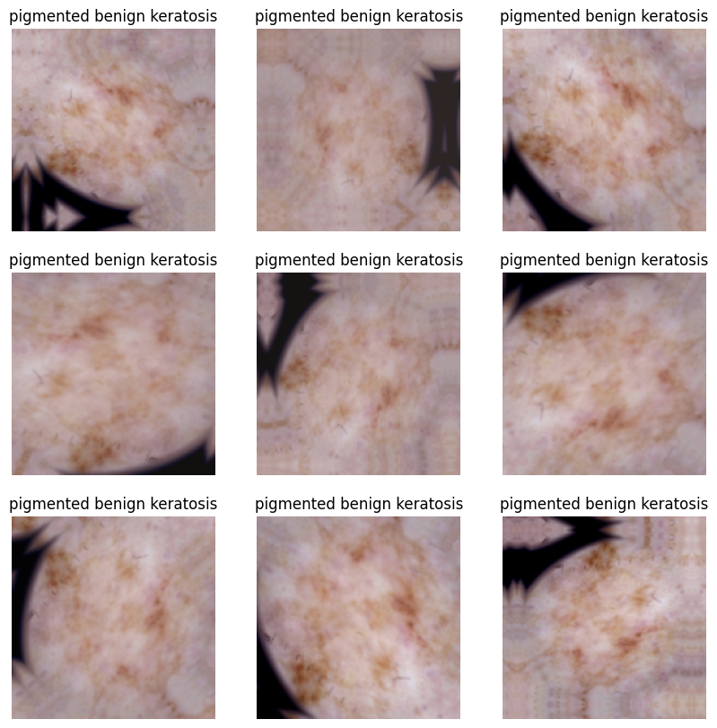

```python
plt.figure(figsize=(10, 10))

images, labels = next(iter(train_aug_ds))

img, lab = images[0], labels[0].numpy()
img = tf.cast(tf.expand_dims(img, 0), tf.float32)
for index in range(9):
    ax = plt.subplot(3, 3, index + 1)
    aug_img = aug_layers(img, training=True)
    plt.imshow(aug_img[0])
    plt.title(class_names[lab])
    plt.axis("off")
```

```python
snet = SqueezeNet()

model = snet.build_model(n_classes=9, choice='bypass', input_shape=(180, 180, 3))
opt = tf.keras.optimizers.Adam(learning_rate=0.001) #
model.compile(optimizer= opt,
              loss= tf.keras.losses.SparseCategoricalCrossentropy(from_logits=False),
              metrics=['accuracy'])
```

```python
ckpt_cb = tf.keras.callbacks.ModelCheckpoint(filepath="baseline_snet_weights_augmented_data.hdf5", monitor="val_accuracy", verbose=1, save_best_only=True, save_weights_only=False)
```

```python
epochs = 40
history = model.fit(
    train_aug_ds,
    validation_data=valid_aug_ds,
    epochs=epochs,
    callbacks=[es_cb, rdr_cb, ckpt_cb],
)
```

```
Epoch 1: val_accuracy improved from -inf to 0.25056, saving model to baseline_snet_weights_augmented_data.hdf5
Epoch 2: val_accuracy improved from 0.25056 to 0.34899, saving model to baseline_snet_weights_augmented_data.hdf5
Epoch 3: val_accuracy did not improve from 0.34899
Epoch 4: val_accuracy improved from 0.34899 to 0.36689, saving model to baseline_snet_weights_augmented_data.hdf5
Epoch 5: val_accuracy did not improve from 0.36689
Epoch 6: val_accuracy did not improve from 0.36689
Epoch 7: val_accuracy improved from 0.36689 to 0.44295, saving model to baseline_snet_weights_augmented_data.hdf5
Epoch 8: val_accuracy did not improve from 0.44295
Epoch 9: val_accuracy did not improve from 0.44295
Epoch 10: val_accuracy did not improve from 0.44295
Epoch 11: val_accuracy did not improve from 0.44295
Epoch 12: ReduceLROnPlateau reducing learning rate to 0.0005000000237487257.

Epoch 12: val_accuracy did not improve from 0.44295
Epoch 13: val_accuracy improved from 0.44295 to 0.55257, saving model to baseline_snet_weights_augmented_data.hdf5
Epoch 14: val_accuracy did not improve from 0.55257
Epoch 15: val_accuracy did not improve from 0.55257
Epoch 16: val_accuracy improved from 0.55257 to 0.57047, saving model to baseline_snet_weights_augmented_data.hdf5
Epoch 17: val_accuracy did not improve from 0.57047
Epoch 18: val_accuracy did not improve from 0.57047
Epoch 19: val_accuracy did not improve from 0.57047
Epoch 20: val_accuracy did not improve from 0.57047
Epoch 21: ReduceLROnPlateau reducing learning rate to 0.0002500000118743628.

Epoch 21: val_accuracy did not improve from 0.57047
Epoch 22: val_accuracy improved from 0.57047 to 0.57494, saving model to baseline_snet_weights_augmented_data.hdf5
Epoch 23: val_accuracy did not improve from 0.57494
Epoch 24: val_accuracy improved from 0.57494 to 0.57942, saving model to baseline_snet_weights_augmented_data.hdf5
Epoch 25: val_accuracy improved from 0.57942 to 0.61969, saving model to baseline_snet_weights_augmented_data.hdf5
Epoch 26: val_accuracy did not improve from 0.61969
Epoch 27: val_accuracy did not improve from 0.61969
Epoch 28: val_accuracy did not improve from 0.61969
Epoch 29: val_accuracy did not improve from 0.61969
Epoch 30: ReduceLROnPlateau reducing learning rate to 0.0001250000059371814.

Epoch 30: val_accuracy did not improve from 0.61969
Epoch 31: val_accuracy did not improve from 0.61969
Epoch 32: val_accuracy did not improve from 0.61969
Epoch 33: val_accuracy did not improve from 0.61969
Epoch 34: val_accuracy did not improve from 0.61969

Epoch 35: val_accuracy did not improve from 0.61969
Epoch 35: early stopping
```

```python
print(f"Early Stopping at Epoch : {es_cb.best_epoch + 1}")
print(f"Train Acc at Epoch {es_cb.best_epoch} : {history.history['accuracy'][es_cb.best_epoch]: .2f}")
print(f"Valid Acc at Epoch {es_cb.best_epoch} : {history.history['val_accuracy'][es_cb.best_epoch]: .2f}")
```

```
Early Stopping at Epoch : 25
Train Acc at Epoch 24 :  0.62
Valid Acc at Epoch 24 :  0.62
```

### Visualizing the training results after augmentation

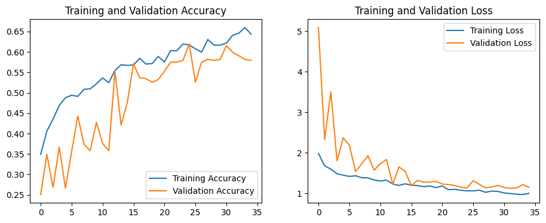

```python
acc = history.history['accuracy']
val_acc = history.history['val_accuracy']

loss = history.history['loss']
val_loss = history.history['val_loss']

epochs_range = range(len(acc))

plt.figure(figsize=(11, 4))
plt.subplot(1, 2, 1)
plt.plot(epochs_range, acc, label='Training Accuracy')
plt.plot(epochs_range, val_acc, label='Validation Accuracy')
plt.legend(loc='lower right')
plt.title('Training and Validation Accuracy')

plt.subplot(1, 2, 2)
plt.plot(epochs_range, loss, label='Training Loss')
plt.plot(epochs_range, val_loss, label='Validation Loss')
plt.legend(loc='upper right')
plt.title('Training and Validation Loss')
plt.show()
```

### Metrics after Data Augmentation :

- Train Acc : 62%
- Valid Acc : 62%

### Findings :

- The training is smoother, i.e. the difference between the training curve and validation curve is smaller showing a good training.
- We can see that the validation accuracy has increased from 59 to 62, this is due to better training happening due to the augmentation layers being used.
- Training Accuracy is decreased from 75 to 62 which is a steep decrease, so there's an opportunity to add a FCN layer to fit better as this might be a underfit.

## Tackling Class Imbalance

To use `Augmentor`, the following general procedure is followed:

1. Instantiate a `Pipeline` object pointing to a directory containing your initial image data set.
2. Define a number of operations to perform on this data set using your `Pipeline` object.
3. Execute these operations by calling the `Pipeline’s` `sample()` method.

```python
path_to_training_dataset = "../../data/CNN_assignment/Train/"
```

```python
import Augmentor

for i in class_names:
    p = Augmentor.Pipeline(path_to_training_dataset + i)
    p.rotate(probability=0.7, max_left_rotation=10, max_right_rotation=10)
    p.sample(500) ## We are adding 500 samples per class to make sure that none of the classes are sparse.
```

```
Initialised with 114 image(s) found.
Output directory set to ../../data/CNN_assignment/Train/actinic keratosis\output.
```

```
Processing <PIL.Image.Image image mode=RGB size=600x450 at 0x2037C630EB0>: 100%|██████████| 500/500 [00:03<00:00, 163.11 Samples/s]
```

```
Initialised with 376 image(s) found.
Output directory set to ../../data/CNN_assignment/Train/basal cell carcinoma\output.
```

```
Processing <PIL.JpegImagePlugin.JpegImageFile image mode=RGB size=600x450 at 0x2037F9D1580>: 100%|██████████| 500/500 [00:03<00:00, 156.81 Samples/s]
```

```
Initialised with 95 image(s) found.
Output directory set to ../../data/CNN_assignment/Train/dermatofibroma\output.
```

```
Processing <PIL.JpegImagePlugin.JpegImageFile image mode=RGB size=600x450 at 0x2038184B100>: 100%|██████████| 500/500 [00:03<00:00, 156.46 Samples/s]
```

```
Initialised with 438 image(s) found.
Output directory set to ../../data/CNN_assignment/Train/melanoma\output.
```

```
Processing <PIL.Image.Image image mode=RGB size=963x629 at 0x2037C611280>: 100%|██████████| 500/500 [00:14<00:00, 34.71 Samples/s]
```

```
Initialised with 357 image(s) found.
Output directory set to ../../data/CNN_assignment/Train/nevus\output.
```

```
Processing <PIL.Image.Image image mode=RGB size=2048x1536 at 0x2037C4A3280>: 100%|██████████| 500/500 [00:13<00:00, 38.43 Samples/s]
```

```
Initialised with 462 image(s) found.
Output directory set to ../../data/CNN_assignment/Train/pigmented benign keratosis\output.
```

```
Processing <PIL.Image.Image image mode=RGB size=600x450 at 0x2037C54AF40>: 100%|██████████| 500/500 [00:03<00:00, 157.53 Samples/s]
```

```
Initialised with 77 image(s) found.
Output directory set to ../../data/CNN_assignment/Train/seborrheic keratosis\output.
```

```
Processing <PIL.Image.Image image mode=RGB size=1024x768 at 0x2037F9AE8E0>: 100%|██████████| 500/500 [00:06<00:00, 72.13 Samples/s]
```

```
Initialised with 181 image(s) found.
Output directory set to ../../data/CNN_assignment/Train/squamous cell carcinoma\output.
```

```
Processing <PIL.Image.Image image mode=RGB size=600x450 at 0x2037C611A60>: 100%|██████████| 500/500 [00:02<00:00, 188.96 Samples/s]
```

```
Initialised with 139 image(s) found.
Output directory set to ../../data/CNN_assignment/Train/vascular lesion\output.
```

```
Processing <PIL.Image.Image image mode=RGB size=600x450 at 0x20380C140A0>: 100%|██████████| 500/500 [00:02<00:00, 184.23 Samples/s]
```

Augmentor has stored the augmented images in the output sub-directory of each of the sub-directories of skin cancer types.. Lets take a look at total count of augmented images.

```python
image_count_train = len(list(data_dir_train.glob('*/output/*.jpg')))
print(image_count_train)
```

```
4500
```

### Lets see the distribution of augmented data after adding new images to the original training data.

```
total training image count = 4500

-------------------------------------
Class name =  actinic keratosis
count      =  500
proportion =  0.1111111111111111
-------------------------------------
Class name =  basal cell carcinoma
count      =  500
proportion =  0.1111111111111111
-------------------------------------
Class name =  dermatofibroma
count      =  500
proportion =  0.1111111111111111
-------------------------------------
Class name =  melanoma
count      =  500
proportion =  0.1111111111111111
-------------------------------------
Class name =  nevus
count      =  500
proportion =  0.1111111111111111
-------------------------------------
Class name =  pigmented benign keratosis
count      =  500
proportion =  0.1111111111111111
-------------------------------------
Class name =  seborrheic keratosis
count      =  500
proportion =  0.1111111111111111
-------------------------------------
Class name =  squamous cell carcinoma
count      =  500
proportion =  0.1111111111111111
-------------------------------------
Class name =  vascular lesion
count      =  500
proportion =  0.1111111111111111
-------------------------------------
```

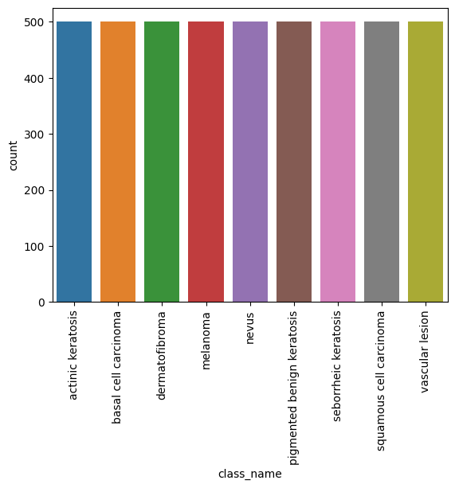

```python
num_classes = len(class_names)
total = 0
all_count = []
class_name = []
for i in range(num_classes):
    count = len(list(data_dir_train.glob(class_names[i]+'/output/*.jpg')))
    total += count
print("total training image count = {} \n".format(total))
print("-------------------------------------")
for i in range(num_classes):
    count = len(list(data_dir_train.glob(class_names[i]+'/output/*.jpg')))
    print("Class name = ",class_names[i])
    print("count      = ",count)
    print("proportion = ",count/total)
    print("-------------------------------------")
    all_count.append(count)
    class_name.append(class_names[i])

temp_df = pd.DataFrame(list(zip(all_count, class_name)), columns = ['count', 'class_name'])
sns.barplot(data=temp_df, y="count", x="class_name")
plt.xticks(rotation=90)
plt.show()
```

So, now we have added 500 images to all the classes to maintain some class balance. We can add more images as we want to improve training process.

### Training with Balanced Dataset

```python
batch_size = 32
img_height = 180
img_width = 180
```

#### Creating the Training Dataset

```python
data_dir_train = pathlib.Path("../../data/CNN_assignment/Augmented Data/Train")
```

```python
train_ds = tf.keras.preprocessing.image_dataset_from_directory(
    data_dir_train,
    seed=DEFAULT_RANDOM_SEED,
    validation_split = 0.2,
    subset = "training",
    image_size=(img_height, img_width),
    batch_size=batch_size)
```

```
Found 4500 files belonging to 9 classes.
Using 3600 files for training.
```

#### **Todo:** Create a validation dataset

```python
val_ds = tf.keras.preprocessing.image_dataset_from_directory(
    data_dir_train,
    seed=DEFAULT_RANDOM_SEED,
    validation_split = 0.2,
    subset = "validation",
    image_size=(img_height, img_width),
    batch_size=batch_size
)
```

```
Found 4500 files belonging to 9 classes.
Using 900 files for validation.
```

```python
snet = SqueezeNet()

model = snet.build_model(n_classes=9, choice='bypass', input_shape=(180, 180, 3))
opt = tf.keras.optimizers.Adam(learning_rate=0.001) #
model.compile(optimizer= opt,
              loss= tf.keras.losses.SparseCategoricalCrossentropy(from_logits=False),
              metrics=['accuracy'])
```

```python
ckpt_cb = tf.keras.callbacks.ModelCheckpoint(
    filepath="baseline_snet_weights_augmented_and_balanced_data.hdf5", monitor="val_accuracy",
    verbose=1, save_best_only=True, save_weights_only=False)
```

```python
epochs = 60
history = model.fit(
    train_ds,
    validation_data=val_ds,
    epochs=epochs,
    callbacks=[es_cb, rdr_cb, ckpt_cb],
)
```

```
Epoch 1: val_accuracy improved from -inf to 0.24000, saving model to baseline_snet_weights_augmented_and_balanced_data.hdf5
Epoch 2: val_accuracy improved from 0.24000 to 0.34556, saving model to baseline_snet_weights_augmented_and_balanced_data.hdf5
Epoch 3: val_accuracy improved from 0.34556 to 0.37333, saving model to baseline_snet_weights_augmented_and_balanced_data.hdf5
Epoch 4: val_accuracy did not improve from 0.37333
Epoch 5: val_accuracy improved from 0.37333 to 0.39889, saving model to baseline_snet_weights_augmented_and_balanced_data.hdf5
Epoch 6: val_accuracy improved from 0.39889 to 0.42778, saving model to baseline_snet_weights_augmented_and_balanced_data.hdf5
Epoch 7: val_accuracy did not improve from 0.42778
Epoch 8: val_accuracy improved from 0.42778 to 0.49778, saving model to baseline_snet_weights_augmented_and_balanced_data.hdf5
Epoch 9: val_accuracy did not improve from 0.49778
Epoch 10: val_accuracy improved from 0.49778 to 0.56444, saving model to baseline_snet_weights_augmented_and_balanced_data.hdf5
Epoch 11: val_accuracy improved from 0.56444 to 0.64000, saving model to baseline_snet_weights_augmented_and_balanced_data.hdf5
Epoch 12: val_accuracy did not improve from 0.64000
Epoch 13: val_accuracy did not improve from 0.64000
Epoch 14: val_accuracy did not improve from 0.64000
Epoch 15: val_accuracy did not improve from 0.64000
Epoch 16: ReduceLROnPlateau reducing learning rate to 0.0005000000237487257.

Epoch 16: val_accuracy did not improve from 0.64000
Epoch 17: val_accuracy improved from 0.64000 to 0.64333, saving model to baseline_snet_weights_augmented_and_balanced_data.hdf5
Epoch 18: val_accuracy did not improve from 0.64333
Epoch 19: val_accuracy did not improve from 0.64333
Epoch 20: val_accuracy improved from 0.64333 to 0.75778, saving model to baseline_snet_weights_augmented_and_balanced_data.hdf5
Epoch 21: val_accuracy did not improve from 0.75778
Epoch 22: val_accuracy did not improve from 0.75778
Epoch 23: val_accuracy improved from 0.75778 to 0.77333, saving model to baseline_snet_weights_augmented_and_balanced_data.hdf5
Epoch 24: val_accuracy did not improve from 0.77333
Epoch 25: ReduceLROnPlateau reducing learning rate to 0.0002500000118743628.

Epoch 25: val_accuracy did not improve from 0.77333
Epoch 26: val_accuracy improved from 0.77333 to 0.80556, saving model to baseline_snet_weights_augmented_and_balanced_data.hdf5
Epoch 27: val_accuracy improved from 0.80556 to 0.82111, saving model to baseline_snet_weights_augmented_and_balanced_data.hdf5
Epoch 28: val_accuracy did not improve from 0.82111
Epoch 29: val_accuracy did not improve from 0.82111
Epoch 30: val_accuracy did not improve from 0.82111
Epoch 31: val_accuracy did not improve from 0.82111
Epoch 32: val_accuracy did not improve from 0.82111
Epoch 33: val_accuracy improved from 0.82111 to 0.82444, saving model to baseline_snet_weights_augmented_and_balanced_data.hdf5
Epoch 34: ReduceLROnPlateau reducing learning rate to 0.0001250000059371814.

Epoch 34: val_accuracy did not improve from 0.82444
```

[output cut: 15 more lines]

```
Epoch 48: val_accuracy improved from 0.85556 to 0.86000, saving model to baseline_snet_weights_augmented_and_balanced_data.hdf5
Epoch 49: val_accuracy did not improve from 0.86000
Epoch 50: val_accuracy did not improve from 0.86000
Epoch 51: val_accuracy did not improve from 0.86000
Epoch 52: ReduceLROnPlateau reducing learning rate to 3.125000148429535e-05.

Epoch 52: val_accuracy did not improve from 0.86000
Epoch 53: val_accuracy did not improve from 0.86000
Epoch 54: val_accuracy did not improve from 0.86000
Epoch 55: val_accuracy did not improve from 0.86000
Epoch 56: val_accuracy did not improve from 0.86000
Epoch 57: val_accuracy did not improve from 0.86000

Epoch 58: val_accuracy did not improve from 0.86000
Epoch 58: early stopping
```

```python
print(f"Early Stopping at Epoch : {es_cb.best_epoch + 1}")
print(f"Train Acc at Epoch {es_cb.best_epoch} : {history.history['accuracy'][es_cb.best_epoch]: .2f}")
print(f"Valid Acc at Epoch {es_cb.best_epoch} : {history.history['val_accuracy'][es_cb.best_epoch]: .2f}")
```

```
Early Stopping at Epoch : 48
Train Acc at Epoch 47 :  0.98
Valid Acc at Epoch 47 :  0.86
```

### Visualizing the model results

[figure not shown]

```python
acc = history.history['accuracy']
val_acc = history.history['val_accuracy']

loss = history.history['loss']
val_loss = history.history['val_loss']

epochs_range = range(es_cb.best_epoch + 1)

plt.figure(figsize=(11, 4))
plt.subplot(1, 2, 1)
plt.plot(epochs_range, acc, label='Training Accuracy')
plt.plot(epochs_range, val_acc, label='Validation Accuracy')
plt.legend(loc='lower right')
plt.title('Training and Validation Accuracy')

plt.subplot(1, 2, 2)
plt.plot(epochs_range, loss, label='Training Loss')
plt.plot(epochs_range, val_loss, label='Validation Loss')
plt.legend(loc='upper right')
plt.title('Training and Validation Loss')
plt.show()
```

Our Model early stopped at Epoch 48 and from the graph above we can analyze that after epoch 48 the training accuracy curve and validation curve has horizontally saturated and is not majorly increasing.

### Metrics after Data Augmentation :

- Train Acc : **98%**
- Valid Acc : **86%**

### Confusion Matrix

```python
val_preds = model.predict(val_ds)
val_preds = np.argmax(val_preds, axis=1)
val_preds.shape
```

```
(900,)
```

```python
val_y = np.concatenate([y for x, y in val_ds], axis=0)
val_y.shape
```

```
(900,)
```

```
Confusion matrix, without normalization
[[15  9 11  8 13 14 13 12 11]
 [15  6  9  8  7 10  9 12  8]
 [13 10  7 10  7  9 15 12 14]
 [14  8 11 10  6  6 13 17  9]
 [16  8  8 15  8 11  9 13 16]
 [ 9  8 11 10 11 11 19  9 14]
 [13  2 21 10 11 13 11 11  7]
 [21 10 17 12 15 13  9 15  6]
 [15  7 12  9 12  5  9 12 15]]
```

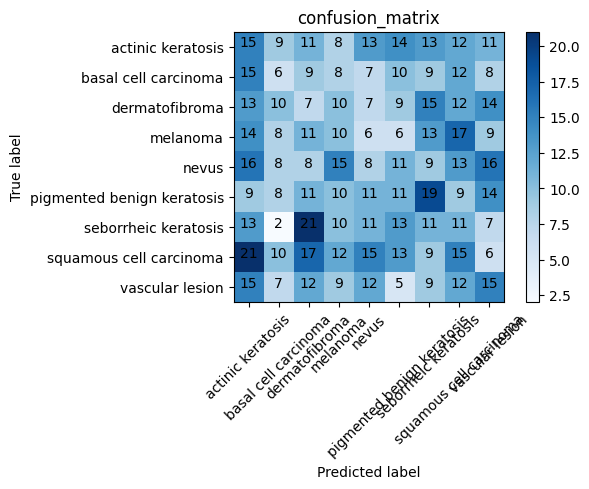

```python
cm_plot_labels = class_names

cm = confusion_matrix(y_true=val_y, y_pred=val_preds)
plot_confusion_matrix(cm=cm, classes=cm_plot_labels, title='confusion_matrix')
```